# Mortgaged Housing Sales Forecasting

### Sude Yagmur Ozturk

The aim of this study is to build a model by analyzing the monthly data between January 2013 and November 2020 in order to forecast the mortgaged housing sales in December 2020.

# Introduction

First of all, I did not know what mortgaged housing sale is when I was assigned this topic. My starting point was to research into news and blogs about mortgaged sales, which are included in References section. Then I called my parents to have more information and verify my findings. I learned that mortgaged sales are a type of housing sales which buyer can lose the mortgaged building when they can not pay their debts. Buyers generally take out mortgage loans from a bank to buy a building and bank mortgages the building as assurance in case of insolvency. A mortgaged house cannot be sold until it is released, but second hand sales occur by changing the mortgagor. This procedure does not seem safe, so real estate websites do not suggest that. Also, this procedure occurs rarely. Consequently, I thought that people usually buy mortgaged houses by owing to banks. In my opinion, two factors can mainly affect mortgaged sales: First one is mortgage loan interest rates and the second one is indices of consumer tendency in housing. Owing to a bank to buy a building makes sense when mortgage loan interest rates decline, vice versa. Also, indices of consumer tendency in housing can be a sign about when people want to buy a building. The data are taken from Data Delivery System of Central Bank of the Republic of Turkey: [EDVS](https://evds2.tcmb.gov.tr/) . There are monthly mortgaged sales statistics, monthly mortgage loans interest rate, and index of consumer tendency in housing between 2013 and 2020. I will first extract and manipulate data, then visualize and analyze the three of them, and build a linear regression model to forecast mortgaged sales statistics in December 2020.

# Manipulation of Data

I firstly did manipulation, such as deleting Turkish characters in rows and unnecessary notes, of the data in Excel. I changed data format into data.table, and changed date values format from character into Date. Therefore, I pasted “-01” at the end of all months. For example, 1st of March represents the whole month -March. For more information, my Rmd file with code chunks is in Appendix. The structure and first entries of mortgaged sales statistics are below.

```
## Classes 'data.table' and 'data.frame':   95 obs. of  2 variables:
##  $ Date           : Date, format: "2013-01-01" "2013-02-01" ...
##  $ Mortgaged_Sales: num  36581 37150 41809 40812 45270 ...
##  - attr(*, ".internal.selfref")=<externalptr>
```

```
##          Date Mortgaged_Sales
## 1: 2013-01-01           36581
## 2: 2013-02-01           37150
## 3: 2013-03-01           41809
## 4: 2013-04-01           40812
## 5: 2013-05-01           45270
## 6: 2013-06-01           43763
```

# Data Visualization and Analysis

There is a line graph which represent monthly mortgaged housing sales from January 2013 to November 2020 below. My aim of study is to find a value for December 2020 by using this data as dependent values.

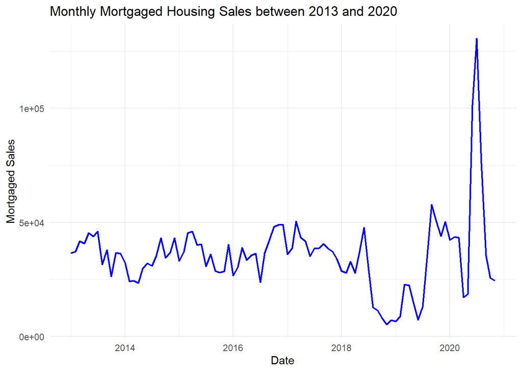

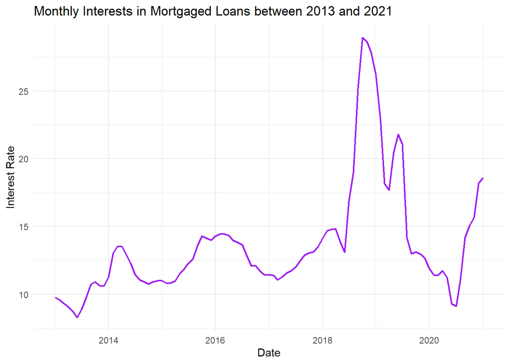

These data are less stationary than the first one, having more jumps after 2018. Remarkable values in 2019 and 2020 differ opposite to Mortgaged Sales, so I expect a negative correlation. Between 2014-2018, auto correlation can be seen in every 24 months. Third graph shows the indices of consumer tendency in housing which are estimated by surveys. These numbers are participants’ rate of the probability of buying or constructing a building in next 12 months.

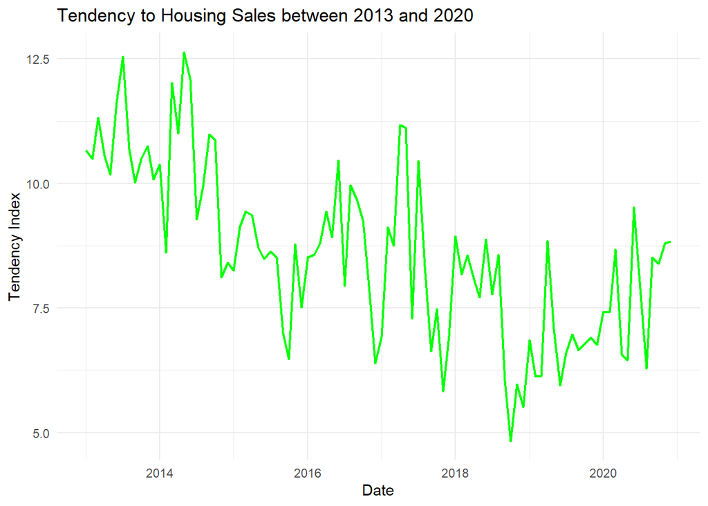

This graph has a negative-sloped trend line until the end of 2018, a positive-sloped trend line afterwards. It seems that the graph has a stationary variance in general and has seasonal effects. I do not think that this second independent variable has a significant correlation with mortgaged sales statistics, but it can be a signal for people’s purchasing power and future exceptations. If one has not enough purchasing power for housing, they may apply for a mortgage loan. Before building a model, I want to check numerically if there is a correlation between these three data.

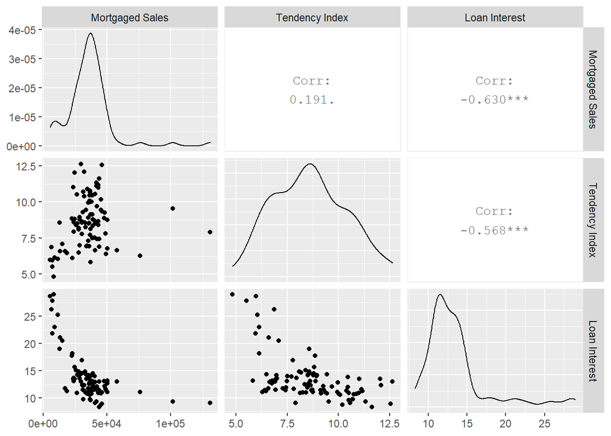

As expected, interest of mortgage loan has significanly negative correlation with tendency to buy a building and with mortgaged sales. Also, tendency indices have positive but relatively less significant correlation with mortgaged sales. I expect that tendency indices’ contribution to my model will be low.

# Adjustments for Stationarity

From first visual inspection, change in variance in mortgaged sales can be seen small. However, y-axis differ in the range of thousands. Thus, we need to take logarithm of these values for a stationary variance.

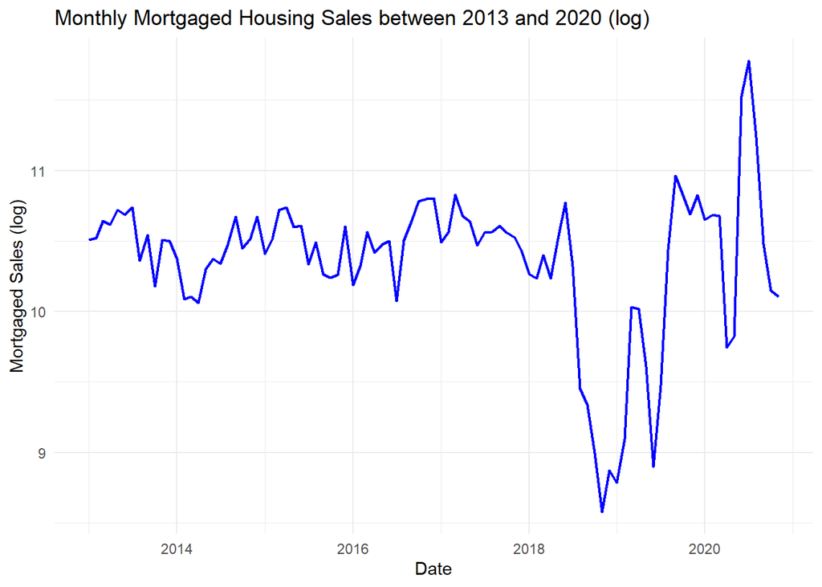

```r
sales_mortgaged[,log_mortgaged := log(Mortgaged_Sales)]
```

Secondly, I need to add month as variables in order to get rid of seasonality. There is the first shape of my linear model below.

```r
fit<- lm(sales_mortgaged$log_mortgaged ~ as.factor(month(sales_mortgaged$Date)))
summary(fit)
```

```
##
## Call:
## lm(formula = sales_mortgaged$log_mortgaged ~ as.factor(month(sales_mortgaged$Date)))
##
## Residuals:
##     Min      1Q  Median      3Q     Max
## -1.6678 -0.1099  0.1070  0.2832  1.3275
##
## Coefficients:
##                                          Estimate Std. Error t value Pr(>|t|)
## (Intercept)                              10.20890    0.19640  51.981   <2e-16
## as.factor(month(sales_mortgaged$Date))2   0.04496    0.27775   0.162    0.872
## as.factor(month(sales_mortgaged$Date))3   0.28728    0.27775   1.034    0.304
## as.factor(month(sales_mortgaged$Date))4   0.10527    0.27775   0.379    0.706
## as.factor(month(sales_mortgaged$Date))5   0.12663    0.27775   0.456    0.650
## as.factor(month(sales_mortgaged$Date))6   0.27090    0.27775   0.975    0.332
## as.factor(month(sales_mortgaged$Date))7   0.24448    0.27775   0.880    0.381
## as.factor(month(sales_mortgaged$Date))8   0.23145    0.27775   0.833    0.407
## as.factor(month(sales_mortgaged$Date))9   0.23038    0.27775   0.829    0.409
## as.factor(month(sales_mortgaged$Date))10  0.06363    0.27775   0.229    0.819
## as.factor(month(sales_mortgaged$Date))11  0.03886    0.27775   0.140    0.889
## as.factor(month(sales_mortgaged$Date))12  0.17854    0.28750   0.621    0.536
##
## (Intercept)                              ***
## as.factor(month(sales_mortgaged$Date))2
## as.factor(month(sales_mortgaged$Date))3
## as.factor(month(sales_mortgaged$Date))4
## as.factor(month(sales_mortgaged$Date))5
## as.factor(month(sales_mortgaged$Date))6
## as.factor(month(sales_mortgaged$Date))7
## as.factor(month(sales_mortgaged$Date))8
## as.factor(month(sales_mortgaged$Date))9
## as.factor(month(sales_mortgaged$Date))10
## as.factor(month(sales_mortgaged$Date))11
## as.factor(month(sales_mortgaged$Date))12
## ---
## Signif. codes:  0 '***' 0.001 '**' 0.01 '*' 0.05 '.' 0.1 ' ' 1
##
## Residual standard error: 0.5555 on 83 degrees of freedom
## Multiple R-squared:  0.03382,    Adjusted R-squared:  -0.09423
## F-statistic: 0.2641 on 11 and 83 DF,  p-value: 0.9906
```

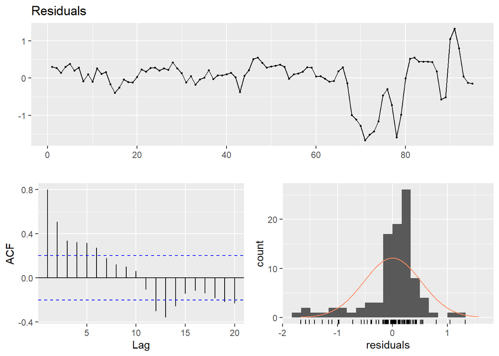

```
##
##  Breusch-Godfrey test for serial correlation of order up to 15
##
## data:  Residuals
## LM test = 78.45, df = 15, p-value = 1.34e-10
```

```r
checkresiduals(fit)
```

According to p-value, residuals, and adjusted R-squared, this model is too horrible to forecast. I will try to add a trend line between 2018-11 and 2020-07.

```r
sales_mortgaged[71:91,trend := 1:21][is.na(trend) == TRUE, trend := 0]
fit<- lm(sales_mortgaged$log_mortgaged ~ sales_mortgaged$trend + as.factor(month(sales_mortgaged$Date)))
summary(fit)
```

```
##
## Call:
## lm(formula = sales_mortgaged$log_mortgaged ~ sales_mortgaged$trend +
##     as.factor(month(sales_mortgaged$Date)))
##
## Residuals:
##      Min       1Q   Median       3Q      Max
## -1.66062 -0.08166  0.13162  0.30293  1.16294
##
## Coefficients:
##                                           Estimate Std. Error t value Pr(>|t|)
## (Intercept)                              10.187438   0.198124  51.419   <2e-16
## sales_mortgaged$trend                     0.009537   0.010731   0.889    0.377
## as.factor(month(sales_mortgaged$Date))2   0.042574   0.278114   0.153    0.879
## as.factor(month(sales_mortgaged$Date))3   0.282511   0.278153   1.016    0.313
## as.factor(month(sales_mortgaged$Date))4   0.098119   0.278218   0.353    0.725
## as.factor(month(sales_mortgaged$Date))5   0.117092   0.278308   0.421    0.675
## as.factor(month(sales_mortgaged$Date))6   0.258978   0.278425   0.930    0.355
## as.factor(month(sales_mortgaged$Date))7   0.230170   0.278567   0.826    0.411
## as.factor(month(sales_mortgaged$Date))8   0.240983   0.278308   0.866    0.389
## as.factor(month(sales_mortgaged$Date))9   0.238730   0.278260   0.858    0.393
## as.factor(month(sales_mortgaged$Date))10  0.070779   0.278218   0.254    0.800
## as.factor(month(sales_mortgaged$Date))11  0.043626   0.278153   0.157    0.876
## as.factor(month(sales_mortgaged$Date))12  0.178195   0.287862   0.619    0.538
##
## (Intercept)                              ***
## sales_mortgaged$trend
## as.factor(month(sales_mortgaged$Date))2
## as.factor(month(sales_mortgaged$Date))3
## as.factor(month(sales_mortgaged$Date))4
## as.factor(month(sales_mortgaged$Date))5
## as.factor(month(sales_mortgaged$Date))6
## as.factor(month(sales_mortgaged$Date))7
## as.factor(month(sales_mortgaged$Date))8
## as.factor(month(sales_mortgaged$Date))9
## as.factor(month(sales_mortgaged$Date))10
## as.factor(month(sales_mortgaged$Date))11
## as.factor(month(sales_mortgaged$Date))12
## ---
## Signif. codes:  0 '***' 0.001 '**' 0.01 '*' 0.05 '.' 0.1 ' ' 1
##
## Residual standard error: 0.5562 on 82 degrees of freedom
## Multiple R-squared:  0.04304,    Adjusted R-squared:  -0.09701
## F-statistic: 0.3073 on 12 and 82 DF,  p-value: 0.9864
```

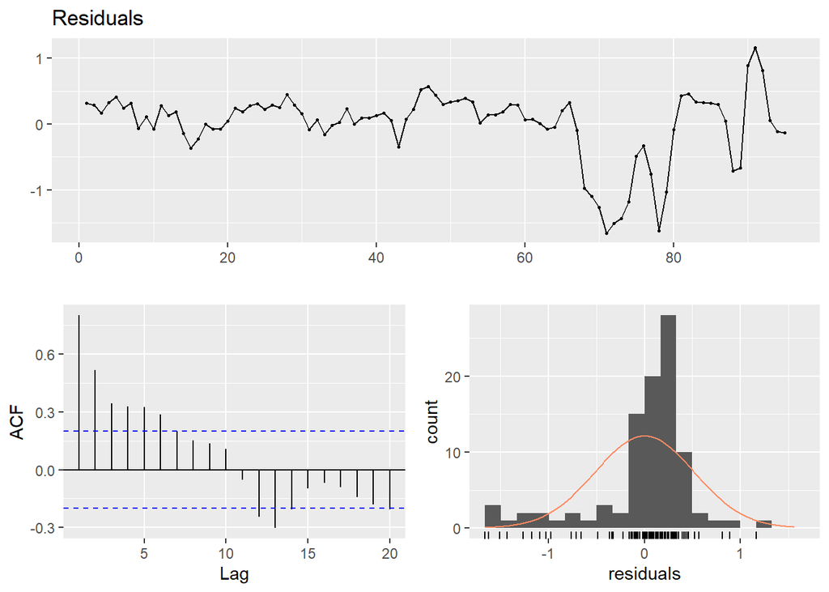

```
##
##  Breusch-Godfrey test for serial correlation of order up to 16
##
## data:  Residuals
## LM test = 78.449, df = 16, p-value = 3.163e-10
```

```r
checkresiduals(fit)
```

# Adding Independent Variables

I think that the interest in mortgage loan as an independent variable can improve my linear model. I expect the coefficient of this variable will be negative. I excluded the last two rows of interest rates for same vector lengths, 95.

```r
fit<- lm(sales_mortgaged$log_mortgaged ~ mortgage_loan_interest$interest_rate[-c(96,97)] + as.factor(month(sales_mortgaged$Date)))
summary(fit)
```

```
##
## Call:
## lm(formula = sales_mortgaged$log_mortgaged ~ mortgage_loan_interest$interest_rate[-c(96,
##     97)] + as.factor(month(sales_mortgaged$Date)))
##
## Residuals:
##      Min       1Q   Median       3Q      Max
## -0.70578 -0.15079  0.01435  0.13946  0.88815
##
## Coefficients:
##                                                   Estimate Std. Error t value
## (Intercept)                                      11.698687   0.134754  86.815
## mortgage_loan_interest$interest_rate[-c(96, 97)] -0.108302   0.006772 -15.991
## as.factor(month(sales_mortgaged$Date))2           0.021538   0.137700   0.156
## as.factor(month(sales_mortgaged$Date))3           0.198445   0.137804   1.440
## as.factor(month(sales_mortgaged$Date))4           0.015226   0.137807   0.110
## as.factor(month(sales_mortgaged$Date))5           0.048361   0.137779   0.351
## as.factor(month(sales_mortgaged$Date))6           0.164838   0.137851   1.196
## as.factor(month(sales_mortgaged$Date))7           0.181044   0.137749   1.314
## as.factor(month(sales_mortgaged$Date))8           0.136006   0.137821   0.987
## as.factor(month(sales_mortgaged$Date))9           0.263329   0.137707   1.912
## as.factor(month(sales_mortgaged$Date))10          0.174941   0.137868   1.269
## as.factor(month(sales_mortgaged$Date))11          0.143003   0.137846   1.037
## as.factor(month(sales_mortgaged$Date))12          0.252629   0.142600   1.772
##                                                  Pr(>|t|)
## (Intercept)                                        <2e-16 ***
## mortgage_loan_interest$interest_rate[-c(96, 97)]   <2e-16 ***
## as.factor(month(sales_mortgaged$Date))2            0.8761
## as.factor(month(sales_mortgaged$Date))3            0.1537
## as.factor(month(sales_mortgaged$Date))4            0.9123
## as.factor(month(sales_mortgaged$Date))5            0.7265
## as.factor(month(sales_mortgaged$Date))6            0.2352
## as.factor(month(sales_mortgaged$Date))7            0.1924
## as.factor(month(sales_mortgaged$Date))8            0.3266
## as.factor(month(sales_mortgaged$Date))9            0.0593 .
## as.factor(month(sales_mortgaged$Date))10           0.2081
## as.factor(month(sales_mortgaged$Date))11           0.3026
## as.factor(month(sales_mortgaged$Date))12           0.0802 .
## ---
## Signif. codes:  0 '***' 0.001 '**' 0.01 '*' 0.05 '.' 0.1 ' ' 1
##
## Residual standard error: 0.2754 on 82 degrees of freedom
## Multiple R-squared:  0.7654, Adjusted R-squared:  0.7311
## F-statistic:  22.3 on 12 and 82 DF,  p-value: < 2.2e-16
```

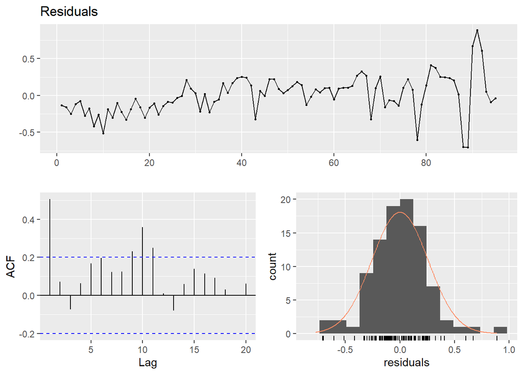

```
##
##  Breusch-Godfrey test for serial correlation of order up to 16
##
## data:  Residuals
## LM test = 53.28, df = 16, p-value = 6.796e-06
```

```r
checkresiduals(fit)
```

According to residual standard error and adjusted R-squared, the interest in mortgage loan as an independent variable improved the linear model. Hoping that I have better result, I added indices of tendency into my linear model.

```r
fit<- lm(sales_mortgaged$log_mortgaged ~ tendency_housing$tendency[-96]+ mortgage_loan_interest$interest_rate[-c(96,97)] + as.factor(month(sales_mortgaged$Date)))
summary(fit)
```

```
##
## Call:
## lm(formula = sales_mortgaged$log_mortgaged ~ tendency_housing$tendency[-96] +
##     mortgage_loan_interest$interest_rate[-c(96, 97)] + as.factor(month(sales_mortgaged$Date)))
##
## Residuals:
##      Min       1Q   Median       3Q      Max
## -0.85724 -0.11226 -0.00393  0.14825  0.79422
##
## Coefficients:
##                                                   Estimate Std. Error t value
## (Intercept)                                      12.272350   0.266033  46.131
## tendency_housing$tendency[-96]                   -0.049842   0.020131  -2.476
## mortgage_loan_interest$interest_rate[-c(96, 97)] -0.119225   0.007914 -15.065
## as.factor(month(sales_mortgaged$Date))2           0.017265   0.133595   0.129
## as.factor(month(sales_mortgaged$Date))3           0.225151   0.134120   1.679
## as.factor(month(sales_mortgaged$Date))4           0.050263   0.134435   0.374
## as.factor(month(sales_mortgaged$Date))5           0.070802   0.133968   0.528
## as.factor(month(sales_mortgaged$Date))6           0.193633   0.134236   1.442
## as.factor(month(sales_mortgaged$Date))7           0.194343   0.133740   1.453
## as.factor(month(sales_mortgaged$Date))8           0.134668   0.133703   1.007
## as.factor(month(sales_mortgaged$Date))9           0.251417   0.133678   1.881
## as.factor(month(sales_mortgaged$Date))10          0.165283   0.133804   1.235
## as.factor(month(sales_mortgaged$Date))11          0.122489   0.133982   0.914
## as.factor(month(sales_mortgaged$Date))12          0.204184   0.139715   1.461
##                                                  Pr(>|t|)
## (Intercept)                                        <2e-16 ***
## tendency_housing$tendency[-96]                     0.0154 *
## mortgage_loan_interest$interest_rate[-c(96, 97)]   <2e-16 ***
## as.factor(month(sales_mortgaged$Date))2            0.8975
## as.factor(month(sales_mortgaged$Date))3            0.0971 .
## as.factor(month(sales_mortgaged$Date))4            0.7095
## as.factor(month(sales_mortgaged$Date))5            0.5986
## as.factor(month(sales_mortgaged$Date))6            0.1530
## as.factor(month(sales_mortgaged$Date))7            0.1500
## as.factor(month(sales_mortgaged$Date))8            0.3168
## as.factor(month(sales_mortgaged$Date))9            0.0636 .
## as.factor(month(sales_mortgaged$Date))10           0.2203
## as.factor(month(sales_mortgaged$Date))11           0.3633
## as.factor(month(sales_mortgaged$Date))12           0.1478
## ---
## Signif. codes:  0 '***' 0.001 '**' 0.01 '*' 0.05 '.' 0.1 ' ' 1
##
## Residual standard error: 0.2672 on 81 degrees of freedom
## Multiple R-squared:  0.7819, Adjusted R-squared:  0.7469
## F-statistic: 22.34 on 13 and 81 DF,  p-value: < 2.2e-16
```

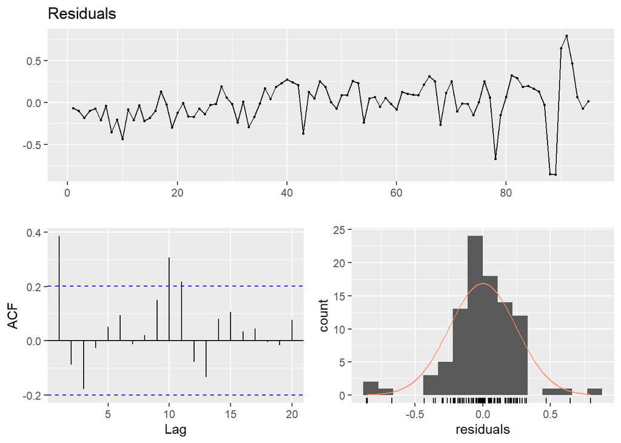

```
##
##  Breusch-Godfrey test for serial correlation of order up to 17
##
## data:  Residuals
## LM test = 50.482, df = 17, p-value = 3.554e-05
```

```r
checkresiduals(fit)
```

# Prediction

Here is my final model.

```
##
## Call:
## lm(formula = sales_mortgaged$log_mortgaged ~ tendency_housing$tendency[-96] +
##     mortgage_loan_interest$interest_rate[-c(96, 97)] + as.factor(month(sales_mortgaged$Date)))
##
## Residuals:
##      Min       1Q   Median       3Q      Max
## -0.85724 -0.11226 -0.00393  0.14825  0.79422
##
## Coefficients:
##                                                   Estimate Std. Error t value
## (Intercept)                                      12.272350   0.266033  46.131
## tendency_housing$tendency[-96]                   -0.049842   0.020131  -2.476
## mortgage_loan_interest$interest_rate[-c(96, 97)] -0.119225   0.007914 -15.065
## as.factor(month(sales_mortgaged$Date))2           0.017265   0.133595   0.129
## as.factor(month(sales_mortgaged$Date))3           0.225151   0.134120   1.679
## as.factor(month(sales_mortgaged$Date))4           0.050263   0.134435   0.374
## as.factor(month(sales_mortgaged$Date))5           0.070802   0.133968   0.528
## as.factor(month(sales_mortgaged$Date))6           0.193633   0.134236   1.442
## as.factor(month(sales_mortgaged$Date))7           0.194343   0.133740   1.453
## as.factor(month(sales_mortgaged$Date))8           0.134668   0.133703   1.007
## as.factor(month(sales_mortgaged$Date))9           0.251417   0.133678   1.881
## as.factor(month(sales_mortgaged$Date))10          0.165283   0.133804   1.235
## as.factor(month(sales_mortgaged$Date))11          0.122489   0.133982   0.914
## as.factor(month(sales_mortgaged$Date))12          0.204184   0.139715   1.461
##                                                  Pr(>|t|)
## (Intercept)                                        <2e-16 ***
## tendency_housing$tendency[-96]                     0.0154 *
## mortgage_loan_interest$interest_rate[-c(96, 97)]   <2e-16 ***
## as.factor(month(sales_mortgaged$Date))2            0.8975
## as.factor(month(sales_mortgaged$Date))3            0.0971 .
## as.factor(month(sales_mortgaged$Date))4            0.7095
## as.factor(month(sales_mortgaged$Date))5            0.5986
## as.factor(month(sales_mortgaged$Date))6            0.1530
## as.factor(month(sales_mortgaged$Date))7            0.1500
## as.factor(month(sales_mortgaged$Date))8            0.3168
## as.factor(month(sales_mortgaged$Date))9            0.0636 .
## as.factor(month(sales_mortgaged$Date))10           0.2203
## as.factor(month(sales_mortgaged$Date))11           0.3633
## as.factor(month(sales_mortgaged$Date))12           0.1478
## ---
## Signif. codes:  0 '***' 0.001 '**' 0.01 '*' 0.05 '.' 0.1 ' ' 1
##
## Residual standard error: 0.2672 on 81 degrees of freedom
## Multiple R-squared:  0.7819, Adjusted R-squared:  0.7469
## F-statistic: 22.34 on 13 and 81 DF,  p-value: < 2.2e-16
```

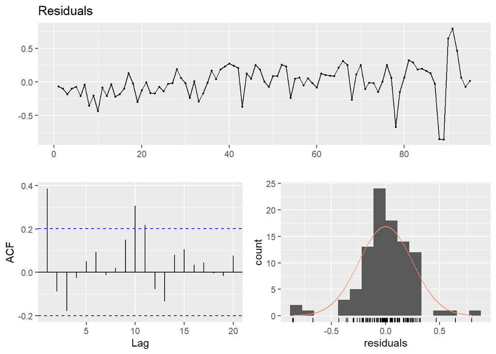

```
##
##  Breusch-Godfrey test for serial correlation of order up to 17
##
## data:  Residuals
## LM test = 50.482, df = 17, p-value = 3.554e-05
```

Here is my fitted values of final model and real values below.

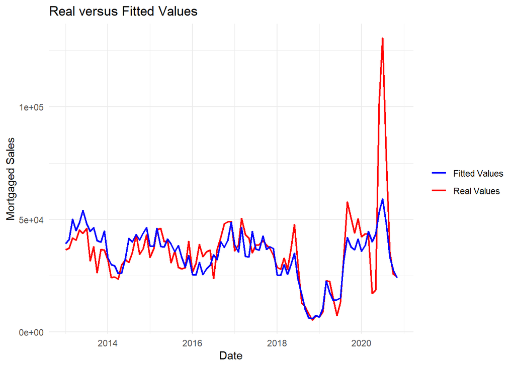

Here is my residuals.

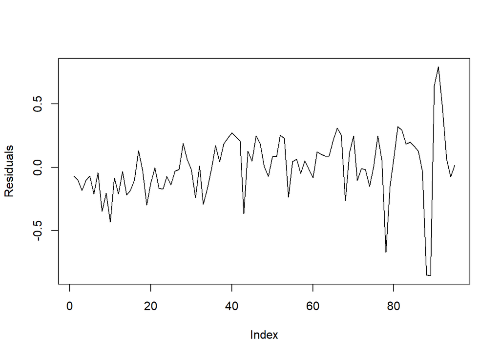

According to this model, my mortgaged housing sales forecast for December 2020 is below.

```r
estimated_val <- exp(12.272350 -0.119225*mortgage_loan_interest$interest_rate[96] + -0.049842*tendency_housing$tendency[96] + 0.204184)
print(estimated_val)
```

```
## [1] 19285.46
```

# Conclusion

# Appendix

Rmd file

# References

[What is mortgaged sales?](https://erolemlak.com/tr/blog/ipotek-nedir-ipotekli-ev-almak-ve-satmak.html) [Buying a mortgaged house](https://www.zingat.com/blog/ipotekli-ev-hakkinda-bilmeniz-gereken-her-sey/) [EVDS](https://evds2.tcmb.gov.tr/index.php?/evds/serieMarket)